# Part I - (Ford GoBike System Data Exploration)

## Introduction

> This data set includes information about individual rides made in a bike-sharing system covering the greater San Francisco Bay area. The features included in the dataset : Trip Duration (seconds) , Start Time and Date , End Time and Date , Start Station ID , Start Station Name , Start Station Latitude , Start Station Longitude , End Station ID , End Station Name, End Station Latitude , End Station Longitude , Bike ID , User Type (Subscriber or Customer – “Subscriber” = Member or “Customer” = Casual) , Member Year of Birth, Member Gender

## Investigation Overview

> This presentation aims to clearify the relationships between the features interduced in the dataset.

> Some Key insightes:

1) most trips are small in distance so that the users reach their destination within 8 - 10 min (around 500 sec)

2) most users do not have bike share for all trip

3) most members are males

4) the 2 most common hours to start riding are 8 am and 5 pm which is predicted since at these times people go to work and leave work

5) it is noted that the most popular start station is: Market St at 10th St

6) it is noted that the most popular end station is: San Francisco Caltrain Station 2 (Townsend St at 4th St)

## Dataset Overview

> The csv file in hand includes a total of 12 columns and 174952 rows. The columns data types differ between int, strings and floats.

### Main feature(s) of interest in your dataset

> Trip Duration , Start Time and Date , End Time and Date, User Type , Member Year of Birth , Member Gender

### Features in the dataset that will help support our investigation into our feature(s) of interest

1) What is the most common hour of the day that people ride bikes?

2) What are the most popular start and end stations?

3) What is the average trip duration every day for each gender?

```python
# import all packages and set plots to be embedded inline
import numpy as np
import pandas as pd
import matplotlib.pyplot as plt
import seaborn as sb

%matplotlib inline

# suppress warnings from final output
import warnings
warnings.simplefilter("ignore")
```

```python
# load in the dataset into a pandas dataframe
df = pd.read_csv('data_clean.csv')
```

## (What is the most common hour of the day that people ride bikes?)

> This visiualiztion will help us to understand at what times during the day were the Ford GoBike is used the most. it would be reasonable to assume the busiest hours are at the beginning and ending of work.

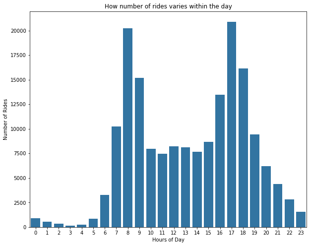

```python
plt.figure(figsize = (10,8))
base_color = sb.color_palette()[0]
sb.countplot(data = df, x = 'hour_of_day', color = base_color);
plt.xlabel('Hours of Day');
plt.ylabel('Number of Rides');
plt.title('How number of rides varies within the day');
```

As we assumed the 2 most common hours to start riding are at the beginning of work (8 am) and at the ending of work (5 pm)

## (What are the most popular start and end stations?)

> with the help of this vesualization we will be able to locate the most popular start point and end point

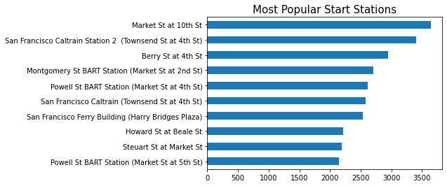

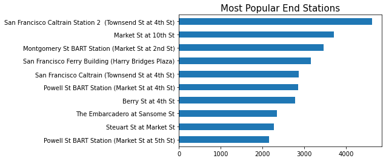

```python
plt.figure(1)
plt.title('Most Popular Start Stations', fontsize=15)
df.start_station_name.value_counts(ascending=True).tail(10).plot.barh();

plt.figure(2)
plt.title('Most Popular End Stations', fontsize=15)
df.end_station_name.value_counts(ascending=True).tail(10).plot.barh();
plt.show()
```

> 1) it is noted that the most popular start station is: Market St at 10th St

> 2) it is noted that the most popular end station is: San Francisco Caltrain Station 2 (Townsend St at 4th St)

## (What is the average trip duration every day for each gender?)

> Using this visualization we will compare the average trip duration every day for each gender

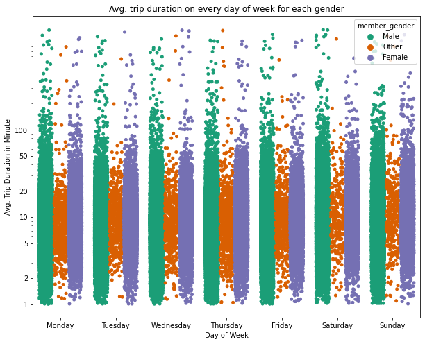

```python
plt.figure(figsize=(10,8))
day_order = ['Monday', 'Tuesday', 'Wednesday', 'Thursday', 'Friday', 'Saturday', 'Sunday']
sb.stripplot(x = "day_of_week", y = "duration_min", hue = 'member_gender', data = df, order = day_order, jitter = 0.35, dodge = True, palette = "Dark2");
plt.xlabel('Day of Week');
plt.ylabel('Avg. Trip Duration in Minute');
plt.yscale('log');
plt.yticks([1, 2, 5, 10, 20, 50, 100], [1, 2, 5, 10, 20, 50, 100]);
ax = plt.gca()
ax.set_yticklabels([],minor = True);
plt.title("Avg. trip duration on every day of week for each gender");
```

## Conclusions

> 1) It is clear now that Males used Ford Bike the most.

> 2) The hours that Ford Bike is mostly used is at 8 am and 5 pm which is predicted since at these times people go to work and leave work.

> 3) It was discovered that the most common start station is Market St at 10th St. And the most common end station is San Francisco Caltrain Station 2 (Townsend St at 4th St)

```python
!jupyter nbconvert Slide_Show.ipynb --to slides --post serve  --no-input --no-prompt
```

```
^C
```